# NHIS 2021 Analysis Report

Celia Lopez

2026-04-16

## Introduction

This report analyzes data from the 2021 National Health Interview Survey (NHIS) to examine relationships between age, height, weight, sex, and education level. The goal is to explore patterns in the data using statistical analysis and visualization in R.

## Methods

The dataset was imported into R and coded to match the NHIS codebook.The key variables include age (AGEP_A), height (HEIGHTTC_A), weight (WEIGHTLBTC_A), sex (SEX_A), and education level (EDUCP_A).

The univariate and bivariate analyses were conducted to understand variable distributions accross relationships. For multivariate analysis, a scatter plot was created to examine the relationship between height and weight.The points are colored by sex and separated by education level. A correlation matrix was also generated to evaluate relationships between age, height, and weight.

## Results

```r
nhis_clean <- read.csv("Data/nhis_clean.csv")
```

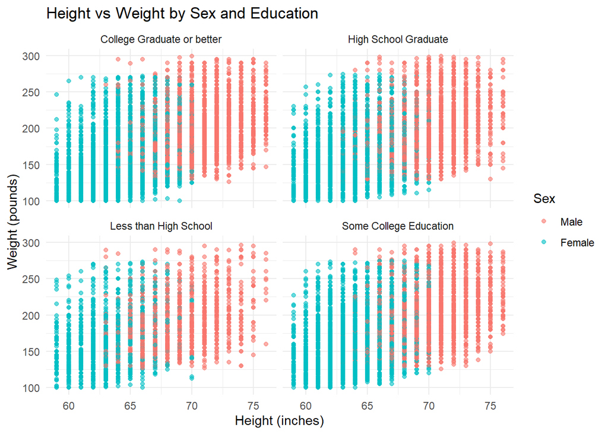

```r
ggplot(nhis_clean, aes(
  x = HEIGHTTC_A,
  y = WEIGHTLBTC_A,
  color = factor(SEX_A, levels = c(1, 2), labels = c("Male", "Female"))
)) +
  geom_point(alpha = 0.6) +
  facet_wrap(~ EDUCP_A) +
  labs(
    title = "Height vs Weight by Sex and Education",
    x = "Height (inches)",
    y = "Weight (pounds)",
    color = "Sex"
  ) +
  theme_minimal()
```

The scatter plot shows a positive relationship between height and weight, meaning taller people usually weigh more. This pattern stays similar across different education levels for both males and females.

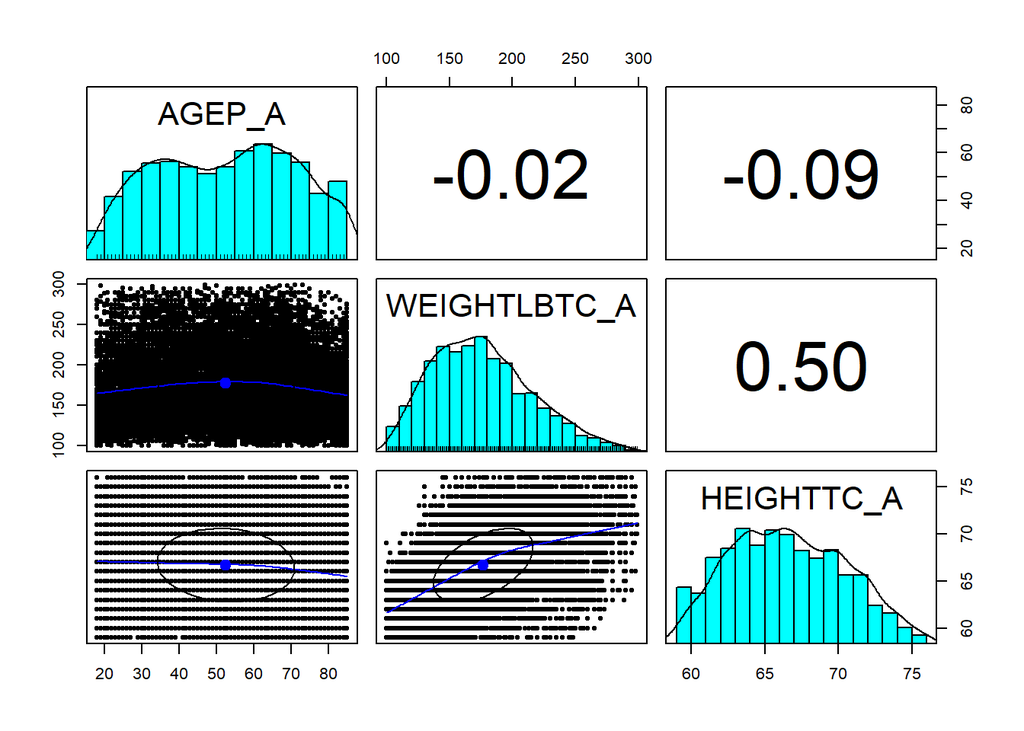

```r
pairs.panels(
  nhis_clean[, c("AGEP_A", "WEIGHTLBTC_A", "HEIGHTTC_A")]
)
```

The correlation matrix supports this, showing a moderate positive relationship between height and weight. Age, on the other hand, has a weaker connection with both height and weight.

## Discussion

The results show that height and weight are closely connected, and this pattern stays about the same across different education levels and for both males and females. The multivariate graph makes it easier to understand because it lets you compare different groups all at once.

One limitation is that only a few variables were used, so it might not include everything that affects a person’s height and weight.

## Conclusion

In conclusion, the analysis shows a clear positive relationship between height and weight. The multivariate graph makes it easier to see how this relationship looks across different sexes and education groups. Overall, this project shows how R can be used to study and visualize public health data in a clear and simple way.